# School Character Analysis

Mackenzie (Mac) Walker

Relevant Packages

```r
library(tidyverse)
library(vegan)
library(MASS)
```

### Overview: Manhattan vs Euclidean Distances

Constructing examples with equal Manhattan distances but differing Euclidean distances

```r
A <- c(2,2,2,2,2,2,2,2,2,2,2)
B <- c(4,2,2,2,2,2,2,2,2,2,2)
C <- c(1,3,2,2,2,2,2,2,2,2,2)

AB <- rbind(A,B)
AC <- rbind(A,C)

dist(AB, method = "euclidean")
##   A
## B 2
dist(AC, method = "euclidean")
##          A
## C 1.414214

dist(AB, method = "manhattan")
##   A
## B 2
dist(AC, method = "manhattan")
##   A
## C 2
```

- **Euclidean distance** is the ‘normal’ distances, which is the sq root taken from the the sum of each variables difference. Therefore euclidean distance essentially works out a straight line by pulling points together.
- **Manhattans distance** on the other hand instead works using the sum of the absolute values; In doing so all points are given an equal weighting and it treats overall difference as additive and accumulate change.

### Metric Multi-Dimensional Scaling (MDS)

```r
data <- read_csv("SchChar.csv", show_col_types = FALSE)
```

##### **Plotting Eigenvalues**

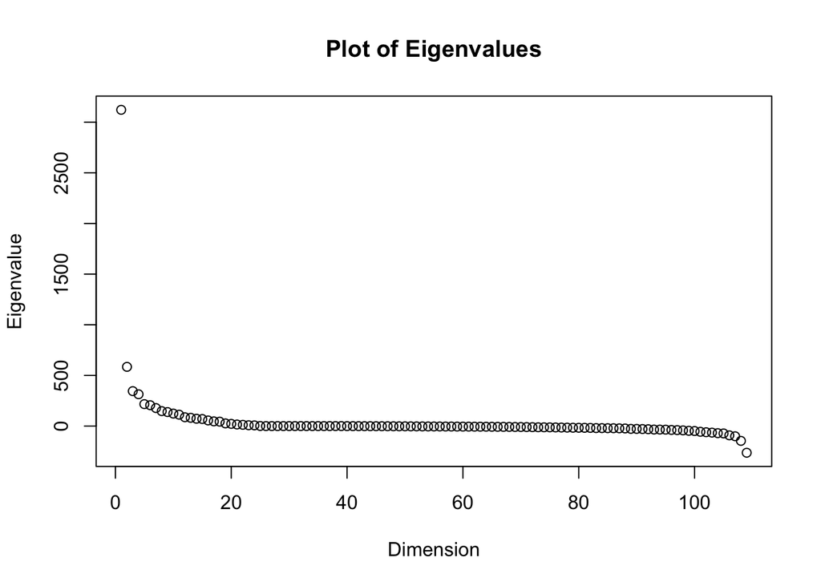

```r
Sch.Resp <- data[,c(2:12)]
Man.Sch.Resp <- dist(Sch.Resp, method = "manhattan")
cmds.Sch.Resp <- cmdscale(Man.Sch.Resp, eig = TRUE)
plot(cmds.Sch.Resp$eig,
        main = "Plot of Eigenvalues",
        ylab = "Eigenvalue",
        xlab = "Dimension")
```

- Are able to see most variance is held in the first dimension;
- When looking for the ‘elbow’, can see drop of after 2, could also looked at the 3rd and 4th dimensions, as there seems to be potentially a small drop off, before it pretty much completely flattens out after 4.

##### **Selecting Dimensions**

```r
k_values <- 2:4
for (k in k_values) {
  cmds <- cmdscale(Man.Sch.Resp, k = k, eig = TRUE)
  cat("k =", k, "GOF:", cmds$GOF, "\n")
}
```

```
## k = 2 GOF: 0.4739983 0.6138596
## k = 3 GOF: 0.5181108 0.6709883
## k = 4 GOF: 0.558274 0.7230023
```

- Can see small increases in the proportion of original distances which are able to be represented with the inclusion of additional dimensions based on the goodness-of-fit output;
- However these are not drastic increases - Indicating that third and fourth dimensions likely do not capture any great amount of variance, with most seeming to be represented in the first.
- Given this, we will use the two dimensional model, with it capturing a significant amount of the variance, and will be easier to visualize

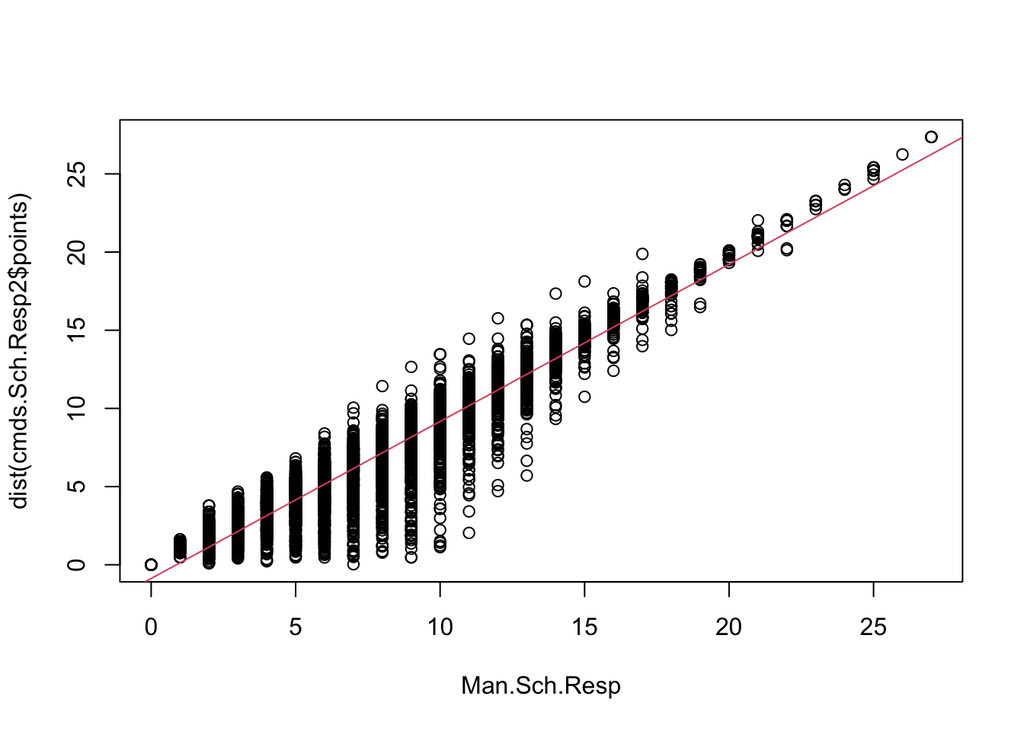

```r
cmds.Sch.Resp2 <- cmdscale(Man.Sch.Resp, k = 2, eig = TRUE)

plot(Man.Sch.Resp, dist(cmds.Sch.Resp2$points))
abline(lm(dist(cmds.Sch.Resp2$points)~Man.Sch.Resp), col = 2)
```

```r
summary(lm(dist(cmds.Sch.Resp2$points)~Man.Sch.Resp))
```

```
##
## Call:
## lm(formula = dist(cmds.Sch.Resp2$points) ~ Man.Sch.Resp)
##
## Residuals:
##     Min      1Q  Median      3Q     Max
## -8.1382 -0.7363  0.4416  0.9264  4.5820
##
## Coefficients:
##               Estimate Std. Error t value Pr(>|t|)
## (Intercept)  -0.877147   0.041970   -20.9   <2e-16 ***
## Man.Sch.Resp  1.004817   0.004727   212.6   <2e-16 ***
## ---
## Signif. codes:  0 '***' 0.001 '**' 0.01 '*' 0.05 '.' 0.1 ' ' 1
##
## Residual standard error: 1.479 on 5884 degrees of freedom
## Multiple R-squared:  0.8848, Adjusted R-squared:  0.8848
## F-statistic: 4.518e+04 on 1 and 5884 DF,  p-value: < 2.2e-16
```

- Somewhat good fit visually, more deviation towards the lower end;
- R squared = 0.88, indicating a reasonably good fit

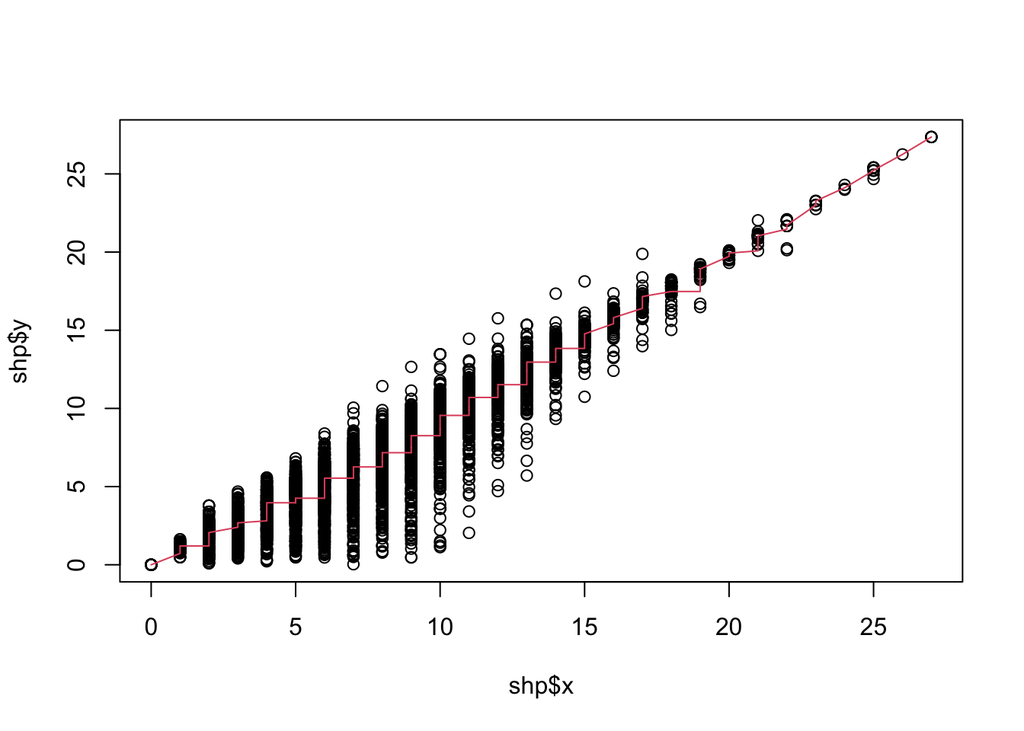

```r
shp <- Shepard(Man.Sch.Resp, cmds.Sch.Resp2$points)
plot(shp)
lines(shp$x, shp$yf, pch = ".", col = 2)
```

### MDS Plots by Location

##### **Plot of first 2 dimensions, of 3D solution**

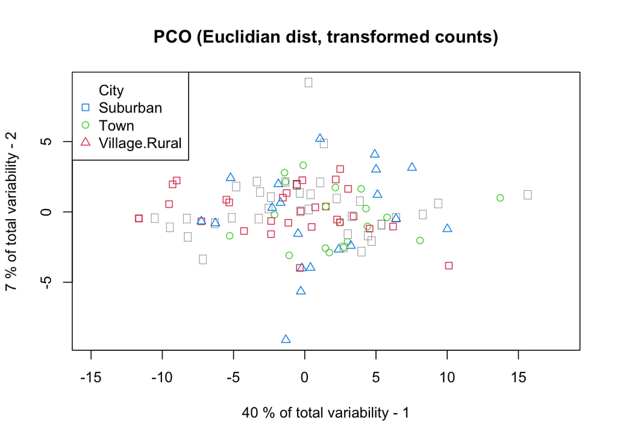

```r
cmds.Sch.Resp3 <- cmdscale(Man.Sch.Resp, k = 3, eig = TRUE)

plot(cmds.Sch.Resp3$points[,1:2], col=as.numeric(as.factor(data$location)), pch= as.numeric(as.factor(data$location))-2,
main='PCO (Euclidian dist, transformed counts)',
xlab=paste(round((cmds.Sch.Resp3$eig/sum(abs(cmds.Sch.Resp3$eig)))[1]*100), "% of total variability - 1") ,
ylab= paste(round((cmds.Sch.Resp3$eig/sum(abs(cmds.Sch.Resp3$eig)))[2]*100), "% of total variability - 2") ,
xlim=c(-15, 18))
legend("topleft", col= as.numeric(as.factor(data$location)),
pch=unique(sort(as.numeric(as.factor(data$location))))-2,
legend=unique(sort(paste(data$location))))
```

- Data quite heavily dispersed;
- No clear grouping or clustering by location type

##### **Plot of first 2 dimensions, of 2D solution, faceted by location**

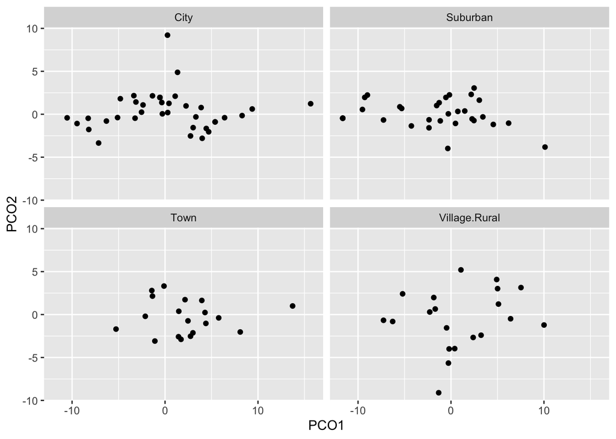

```r
df <- data.frame(PCO1 = cmds.Sch.Resp2$points[,1],
                 PCO2 = cmds.Sch.Resp2$points[,2],
                 Location = (data$location))
df %>%
  ggplot(mapping = aes(x = PCO1,
                       y = PCO2)) +
  facet_wrap(vars(Location)) +
  geom_point()
```

```r
num.loc <- table(data$location)
print(num.loc)
##
##          City      Suburban          Town Village.Rural
##            38            32            19            20
```

- **City Schools:** Spread more heavily along PCO1, potential outliers
- **Suburban Schools:** Again slighter more spread along PCO1, slightly shifted towards the left on this axis as well
- **Town Schools & Village.Rural Schools:** Seems pretty random - quite a few less Town and Village.Rural schools (19 and 20 respectively) then that of city (38) and Suburban (32)

### PERMANOVA

##### **Testing for significant location-based differences**

```r
perm <- adonis2(Sch.Resp~data$location, permutations = 999)
print(perm)
```

```
## Permutation test for adonis under reduced model
## Permutation: free
## Number of permutations: 999
##
## adonis2(formula = Sch.Resp ~ data$location, permutations = 999)
##           Df SumOfSqs      R2      F Pr(>F)
## Model      3  0.16805 0.07423 2.8063  0.016 *
## Residual 105  2.09594 0.92577
## Total    108  2.26399 1.00000
## ---
## Signif. codes:  0 '***' 0.001 '**' 0.01 '*' 0.05 '.' 0.1 ' ' 1
```

### Composite Scoring Evaluation

##### Scenario: Responding to colleague suggestion, based on evaluation - just adding up the school character scores to create an overall character metric, as all are oriented in the same way

```r
df <- df %>%
  mutate(overall.scores = rowSums(data[, 2:12]))

round(cor(cbind(PCO1 = df$PCO1, PCO2 = df$PCO2, OverallScores = df$overall.scores)), 4) %>%
  as.table()
```

```
##                 PCO1   PCO2 OverallScores
## PCO1          1.0000 0.0000        0.9977
## PCO2          0.0000 1.0000        0.0210
## OverallScores 0.9977 0.0210        1.0000
```

- Strong correlation with PCO1 with overall scores,
- Weak correlation between PCO2 and overall scores
- PCO1 captures a lot of the variance, but simple overall sum has the potential to result in loss of the finer details and important information.